# Retail Sales Performance Analysis Using SQL and R

LaToya Burdette

## Overview

This project looks at retail sales data using SQL and R. The goal was to better understand revenue trends across customers, products, categories, suppliers, and regions. I imported the data from Excel, loaded it into a SQLite database, queried it with SQL, and visualized the results in R.

## Total Revenue

| total_revenue |
| --- |
| 1220491 |

## Top 10 Customers by Revenue

| name | total_revenue |
| --- | --- |
| Quinn Hall | 23524.91 |
| Rachel Hill | 22645.75 |
| Isla Walker | 21681.44 |
| Alice King | 20879.52 |
| Emily Adams | 20222.70 |
| Bob Allen | 20123.40 |
| Dan White | 19686.75 |
| Grace White | 19206.10 |
| Henry Parker | 18903.83 |
| Nina Young | 18642.40 |

## Top 10 Products by Revenue

| product_name | total_revenue |
| --- | --- |
| Device O | 52782.04 |
| Appliance AK | 51723.82 |
| Appliance G | 50217.54 |
| Appliance AU | 48417.29 |
| Appliance Q | 46036.88 |
| Appliance AA | 42460.76 |
| Device Y | 40342.98 |
| Gadget V | 35365.49 |
| Device AS | 35275.22 |
| Device AI | 32789.23 |

## Revenue by Category

| category | total_revenue |
| --- | --- |
| Electronics | 448992.58 |
| Home Appliances | 419125.70 |
| Hardware | 191359.03 |
| Accessories | 82420.29 |
| Office Supplies | 78593.71 |

## Revenue by Region

| region | total_revenue |
| --- | --- |
| Midwest | 292618.0 |
| East Coast | 248551.8 |
| South | 235847.9 |
| West Coast | 230042.8 |
| North | 213430.8 |

## Supplier Performance

| supplier_name | total_revenue |
| --- | --- |
| HealthTech Supplies | 238856.29 |
| Office Tech Depot | 190156.60 |
| Tech Gear Co. | 180269.41 |
| Auto Electronics Pro | 138490.10 |
| Gadget World | 120345.88 |
| Gourmet Gadgets | 109206.35 |
| Circuit Solutions | 82152.68 |
| Eco Electronics | 78593.71 |
| Sports Tech Gear | 50602.89 |
| Smart Home Essentials | 31817.40 |

## Monthly Sales Trend

| month | total_revenue |
| --- | --- |
| 2024-01-01 | 113671.47 |
| 2024-02-01 | 100888.62 |
| 2024-03-01 | 107478.72 |
| 2024-04-01 | 101476.52 |
| 2024-05-01 | 101186.62 |
| 2024-06-01 | 94898.53 |
| 2024-07-01 | 102762.07 |
| 2024-08-01 | 101933.32 |
| 2024-09-01 | 105256.50 |
| 2024-10-01 | 97415.08 |
| 2024-11-01 | 95018.86 |
| 2024-12-01 | 98505.00 |

## Visualization: Top Customers

[figure not shown]

## Visualization: Top Products

[figure not shown]

## Visualization: Revenue by Category

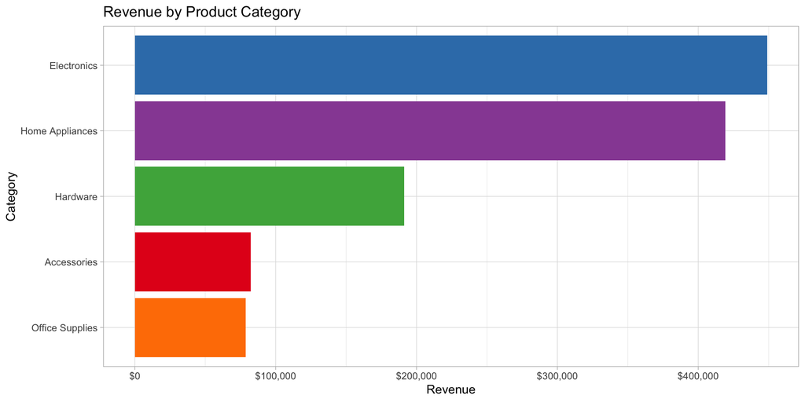

## Visualization: Monthly Sales Trend

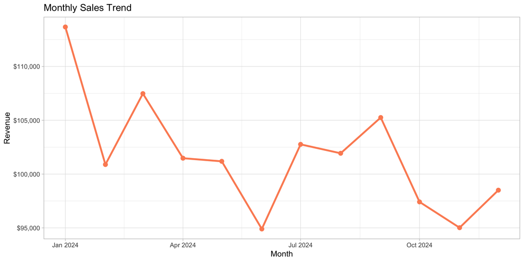

## Conclusion

This project uses SQL and R to analyze retail sales data. SQL was used to join the tables and calculate revenue across customers, products, categories, and regions. R was used to clean the data and create visualizations that make the results easier to see. Overall, the analysis provides a clearer picture of where revenue is coming from and how sales change over time.